# Lyrics

## The analysis of content in lyrics

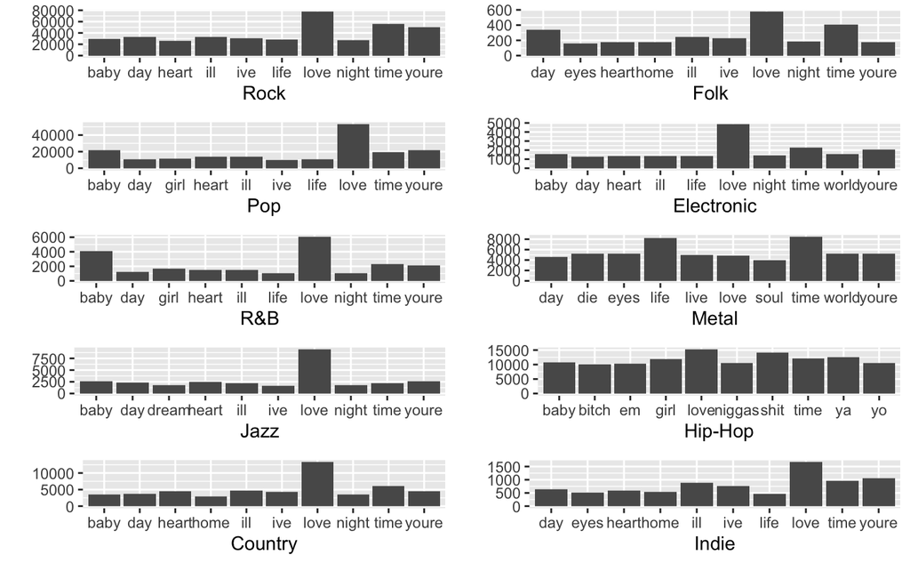

```r
# the definition of multi_plot
# ggplot objects can be passed in ..., or to plotlist (as a list of ggplot objects)
# - cols:   Number of columns in layout
# - layout: A matrix specifying the layout. If present, 'cols' is ignored.
#
# If the layout is something like matrix(c(1,2,3,3), nrow=2, byrow=TRUE),
# then plot 1 will go in the upper left, 2 will go in the upper right, and
# 3 will go all the way across the bottom.
#
multiplot <- function(..., plotlist=NULL, file, cols=1, layout=NULL) {
  require(grid)

  # Make a list from the ... arguments and plotlist
  plots <- c(list(...), plotlist)

  numPlots = length(plots)

  # If layout is NULL, then use 'cols' to determine layout
  if (is.null(layout)) {
    # Make the panel
    # ncol: Number of columns of plots
    # nrow: Number of rows needed, calculated from # of cols
    layout <- matrix(seq(1, cols * ceiling(numPlots/cols)),
                    ncol = cols, nrow = ceiling(numPlots/cols))
  }

 if (numPlots==1) {
    print(plots[[1]])

  } else {
    # Set up the page
    grid.newpage()
    pushViewport(viewport(layout = grid.layout(nrow(layout), ncol(layout))))

    # Make each plot, in the correct location
    for (i in 1:numPlots) {
      # Get the i,j matrix positions of the regions that contain this subplot
      matchidx <- as.data.frame(which(layout == i, arr.ind = TRUE))

      print(plots[[i]], vp = viewport(layout.pos.row = matchidx$row,
                                      layout.pos.col = matchidx$col))
    }
  }
}

# the top10 popular words

rock.top10<-
  dt_lyrics %>%
  dplyr::filter(genre == "Rock") %>%
  dplyr::select(genre, stemmedwords) %>%
  unnest_tokens(word, stemmedwords) %>%
  dplyr::group_by(genre,word) %>%
  dplyr::summarise(count=n()) %>%
  top_n(n=10) %>%
  ggplot() +
  geom_bar(aes(x=word,y=count),stat="identity")+
  labs(x="Rock",
       y=" ")
pop.top10<-
  dt_lyrics %>%
  dplyr::filter(genre == "Pop") %>%
  dplyr::select(genre, stemmedwords) %>%
  unnest_tokens(word, stemmedwords) %>%
  dplyr::group_by(genre,word) %>%
  dplyr::summarise(count=n()) %>%
  top_n(n=10) %>%
  ggplot() +
  geom_bar(aes(x=word,y=count),stat="identity")+
  labs(x="Pop",
       y=" ")
RandB.top10<-
  dt_lyrics %>%
  dplyr::filter(genre == "R&B") %>%
  dplyr::select(genre, stemmedwords) %>%
  unnest_tokens(word, stemmedwords) %>%
  dplyr::group_by(genre,word) %>%
  dplyr::summarise(count=n()) %>%
  top_n(n=10) %>%
  ggplot() +
  geom_bar(aes(x=word,y=count),stat="identity")+
  labs(x="R&B",
       y=" ")
jazz.top10<-
  dt_lyrics %>%
  dplyr::filter(genre == "Jazz") %>%
  dplyr::select(genre, stemmedwords) %>%
  unnest_tokens(word, stemmedwords) %>%
  dplyr::group_by(genre,word) %>%
  dplyr::summarise(count=n()) %>%
  top_n(n=10) %>%
  ggplot() +
  geom_bar(aes(x=word,y=count),stat="identity")+
  labs(x="Jazz",
       y=" ")
country.top10<-
  dt_lyrics %>%
  dplyr::filter(genre == "Country") %>%
  dplyr::select(genre, stemmedwords) %>%
  unnest_tokens(word, stemmedwords) %>%
  dplyr::group_by(genre,word) %>%
  dplyr::summarise(count=n()) %>%
  top_n(n=10) %>%
  ggplot() +
  geom_bar(aes(x=word,y=count),stat="identity")+
  labs(x="Country",
       y=" ")
folk.top10<-
  dt_lyrics %>%
  dplyr::filter(genre == "Folk") %>%
  dplyr::select(genre, stemmedwords) %>%
  unnest_tokens(word, stemmedwords) %>%
  dplyr::group_by(genre,word) %>%
  dplyr::summarise(count=n()) %>%
  top_n(n=10) %>%
  ggplot() +
  geom_bar(aes(x=word,y=count),stat="identity")+
  labs(x="Folk",
       y=" ")
electronic.top10<-
  dt_lyrics %>%
  dplyr::filter(genre == "Electronic") %>%
  dplyr::select(genre, stemmedwords) %>%
  unnest_tokens(word, stemmedwords) %>%
  dplyr::group_by(genre,word) %>%
  dplyr::summarise(count=n()) %>%
  top_n(n=10) %>%
  ggplot() +
  geom_bar(aes(x=word,y=count),stat="identity")+
  labs(x="Electronic",
       y=" ")
metal.top10<-
  dt_lyrics %>%
  dplyr::filter(genre == "Metal") %>%
  dplyr::select(genre, stemmedwords) %>%
  unnest_tokens(word, stemmedwords) %>%
  dplyr::group_by(genre,word) %>%
  dplyr::summarise(count=n()) %>%
  top_n(n=10) %>%
  ggplot() +
  geom_bar(aes(x=word,y=count),stat="identity")+
  labs(x="Metal",
       y=" ")
hiphop.top10<-
  dt_lyrics %>%
  dplyr::filter(genre == "Hip-Hop") %>%
  dplyr::select(genre, stemmedwords) %>%
  unnest_tokens(word, stemmedwords) %>%
  dplyr::group_by(genre,word) %>%
  dplyr::summarise(count=n()) %>%
  top_n(n=10) %>%
  ggplot() +
 geom_bar(aes(x=word,y=count),stat="identity")+
  labs(x="Hip-Hop",
       y=" ")
indie.top10<-
  dt_lyrics %>%
  dplyr::filter(genre == "Indie") %>%
  dplyr::select(genre, stemmedwords) %>%
  unnest_tokens(word, stemmedwords) %>%
  dplyr::group_by(genre,word) %>%
  dplyr::summarise(count=n()) %>%
  top_n(n=10) %>%
  ggplot() +
  geom_bar(aes(x=word,y=count),stat="identity")+
  labs(x="Indie",
       y=" ")
multiplot(rock.top10,pop.top10,RandB.top10,jazz.top10,country.top10,folk.top10,electronic.top10,metal.top10,hiphop.top10,indie.top10,cols=2)
```

As we can see, except for Metal, the love is used most frequently by all the genres, and love is mentioned about 80000 times, which is the highest in all genres. However, in metal music, the terms, life and time, are mentioned more than the term love, and I guess this is resulted by the core of metal music, the aggressive attitude about life rather than the joy of the world. We also can conclude this from the word cloud of metal music’s lyrics

```r
metal.cloud <-
  dt_lyrics %>%
  filter(genre=="Metal") %>%
  select(stemmedwords) %>%
  VectorSource() %>%
  VCorpus()
dtm.metal <- DocumentTermMatrix(metal.cloud)
word.metal <- colnames(as.matrix(dtm.metal))
cloud.metal <- data.frame(word=word.metal,
                         freq=apply(as.matrix(dtm.metal), 2, sum))
cloud.metal <- cloud.metal[order(cloud.metal$freq, decreasing=T), ]
wordcloud2(data=cloud.metal[1:50,], size=0.5,shape="oval")
```

[interactive chart not shown]

## Semtimental analysis

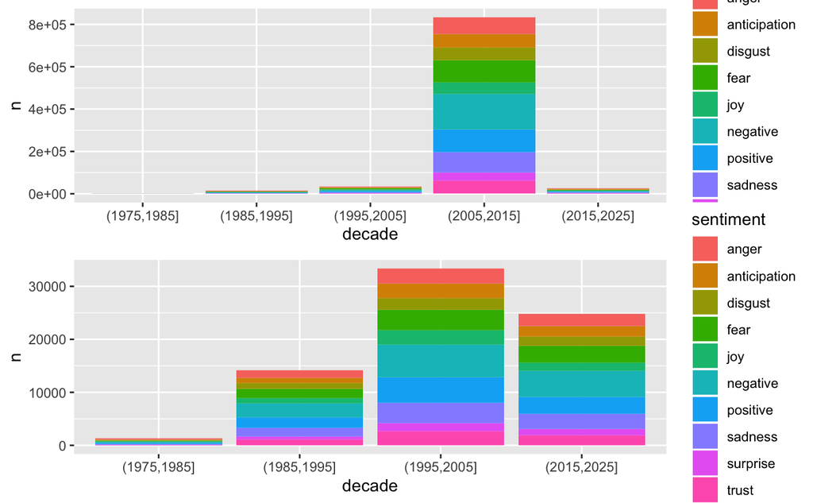

```r
sentiment.list <- get_sentiments("nrc")
metal.sentiment<-
  dt_lyrics %>%
  dplyr::filter(genre=="Metal")%>%
  dplyr::select(genre, stemmedwords) %>%
  unnest_tokens(word, stemmedwords) %>%
  inner_join(sentiment.list,by="word") %>%
  dplyr::group_by(genre,sentiment) %>%
  dplyr::summarise(n=n())

metal.sentiment.decade <-
  dt_lyrics %>%
  dplyr::filter(genre=="Metal") %>%
  dplyr::select(genre, decade, stemmedwords) %>%
  unnest_tokens(word, stemmedwords) %>%
  inner_join(sentiment.list,by="word") %>%
  dplyr::group_by(genre,decade,sentiment) %>%
  dplyr::summarise(n=n())
metal.sentiment.decade_exc_2005_2015 <-
  metal.sentiment.decade %>%
  filter(decade != "(2005,2015]")

p1 <-
  ggplot(metal.sentiment.decade,aes(x=decade,y=n,fill=sentiment))+
  geom_bar(stat="identity")

p2 <-
  ggplot(metal.sentiment.decade_exc_2005_2015,aes(x=decade,y=n,fill=sentiment))+
  geom_bar(stat="identity")
multiplot(p1,p2,cols=1)
```

```r
NA
```

As we can see, the top 5 major feeling of the metal music is negative, positive, fear, sadness and anger, and four of five suggest the darkness of life. Hence, we can infer that the reason why metal music is less often to mention the term love is that its major emotion is the negative. We also can use the sentiment analysis on all the genres to prove that.

```r
sentiment.all <-
  dt_lyrics %>%
  dplyr::select(genre, stemmedwords) %>%
  unnest_tokens(word, stemmedwords) %>%
  inner_join(sentiment.list,by="word") %>%
  dplyr::group_by(genre,sentiment) %>%
  dplyr::summarise(n=n()) %>%
  pivot_wider(names_from = "sentiment",values_from = "n" ) %>%
  ungroup()

sentiment.genre <- sentiment.all$genre
sentiments <- sentiment.all %>% select(-genre) %>% as.matrix()
sentiment.hmp <- diag(1/(apply(sentiment,1,sum))) %*% sentiments
rownames(sentiment.hmp) <- sentiment.genre
d3heatmap(sentiment.hmp,color = "Blues", Rowv=T, Colv=F)
```

[interactive chart not shown]

```r
# trying to figure out which sentiment the term love is corresponding
sentiment.list$sentiment[which(sentiment.list$word=="love")]
```

```
[1] "joy"      "positive"
```

As the result shown, in the sentimental analysis, the term love is corresponding to joy and positive emotion, and also considering what the heatmap is shown，compared to other genres, the metal music has more preference on the negative emotion rather than the joy and positive emotion. So, this is why the metal music relatively rarely mentions the term love.